# Correlaciones entre variables del Censo de Viviendas, Hogares y Personas e ingresos promedios comunales de la CASEN 2017.

VE-CC-AJ

DataIntelligence

Viernes 02-07-2021

Abstract

Calculamos correlaciones entre el ingreso promedio comunal **multiplicado por la población comunal** que llamaremos **ingresos expandidos** extraído de la Casen 2017 y las frecuencias de categorías de respuesta para todas las variables del Censo de viviendas, hogares y personas al 2017, también extraídas a nivel comunal.

Haremos las correlaciones tanto a nivel Urbano como rural.

Importante es aplicar la libreria **dplyr** para evitar que en los filtros se desplieguen series de tiempo.

Area: urbano = 1 rural = 2

# Urbano

## 1 Pregunta **P18**: Rama de actividad económica

1 A Agricultura, ganadería, silvicultura y pesca  
2 B Explotación de minas y canteras  
3 C Industrias manufactureras  
4 D Suministro de electricidad, gas, vapor y aire acondicionado  
5 E Suministro de agua; evacuación de aguas residuales, gestión de desechos y descontaminación  
6 F Construcción  
7 G Comercio al por mayor y al por menor; reparación de vehículos automotores y motocicletas  
8 H Transporte y almacenamiento  
9 I Actividades de alojamiento y de servicios de comidas  
10 J Información y comunicaciones  
11 K Actividades financieras y de seguros  
12 L Actividades inmobiliarias  
13 M Actividades profesionales, científicas y técnicas  
14 N Actividades de servicios administrativos y de apoyo  
15 O Administración pública y defensa; planes de seguridad social de afiliación obligatoria  
16 P Enseñanza  
17 Q Actividades de atención de la salud humana y de asistencia social  
18 R Actividades artísticas, de entretenimiento y recreativas  
19 S Otras actividades de servicios  
20 T Actividades de los hogares como empleadores; actividades no diferenciadas de los hogares como productores de bienes y servicios para uso propio  
21 U Actividades de organizaciones y órganos extraterritoriales  
22 Z Rama no declarada

98 No aplica  
99 Missing

### 1.1 Cálculo de frecuencias

```r
tabla_con_clave <- readRDS("../censo_personas_con_clave_17")
tabla_con_clave <- filter(tabla_con_clave, tabla_con_clave$AREA == 1)

b <- tabla_con_clave$COMUNA
c <- tabla_con_clave$P18
cross_tab =  xtabs( ~ unlist(b) + unlist(c))
tabla <- as.data.frame(cross_tab)
d <-tabla[!(tabla$Freq == 0),]
d$anio <- "2017"

d$unlist.c. <- as.character(d$unlist.c.)
d <- d[-5]

d$unlist.c.[d$unlist.c. == "A"] <- "1"
d$unlist.c.[d$unlist.c. == "B"] <- "2"
d$unlist.c.[d$unlist.c. == "C"] <- "3"
d$unlist.c.[d$unlist.c. == "D"] <- "4"
d$unlist.c.[d$unlist.c. == "E"] <- "5"

d$unlist.c.[d$unlist.c. == "F"] <- "6"
d$unlist.c.[d$unlist.c. == "G"] <- "7"
d$unlist.c.[d$unlist.c. == "H"] <- "8"
d$unlist.c.[d$unlist.c. == "I"] <- "9"
d$unlist.c.[d$unlist.c. == "J"] <- "10"

d$unlist.c.[d$unlist.c. == "K"] <- "11"
d$unlist.c.[d$unlist.c. == "L"] <- "12"
d$unlist.c.[d$unlist.c. == "M"] <- "13"
d$unlist.c.[d$unlist.c. == "N"] <- "14"
d$unlist.c.[d$unlist.c. == "O"] <- "15"

d$unlist.c.[d$unlist.c. == "P"] <- "16"
d$unlist.c.[d$unlist.c. == "Q"] <- "17"
d$unlist.c.[d$unlist.c. == "R"] <- "18"
d$unlist.c.[d$unlist.c. == "S"] <- "19"
d$unlist.c.[d$unlist.c. == "T"] <- "20"

d$unlist.c.[d$unlist.c. == "U"] <- "21"
d$unlist.c.[d$unlist.c. == "Z"] <- "22"

d$unlist.c. <- as.numeric(d$unlist.c.)

d_t <- filter(d,d$unlist.c. == 1)
for(i in 2:22){
  d_i <- filter(d,d$unlist.c. == i)
  d_t = merge( x = d_t, y = d_i, by = "unlist.b.", all.x = TRUE)
}

codigos <- d_t$unlist.b.
rango <- seq(1:nrow(d_t))
cadena <- paste("0",codigos[rango], sep = "")
cadena <- substr(cadena,(nchar(cadena)[rango])-(4),6)
codigos <- as.data.frame(codigos)
cadena <- as.data.frame(cadena)
comuna_corr <- cbind(d_t,cadena)
comuna_corr <- comuna_corr[,-c(1),drop=FALSE]

names(comuna_corr)[67] <- "código"

ingresos_expandidos_2017 <- readRDS("Ingresos_expandidos_urbano_17.rds")

df_2017_2 = merge( x = comuna_corr, y = ingresos_expandidos_2017, by = "código", all.x = TRUE)

names(df_2017_2)[3] <- "Agricultura"
names(df_2017_2)[6] <- "Explotación"
names(df_2017_2)[9] <- "Industrias"
names(df_2017_2)[12] <- "Suministro de electricidad"
names(df_2017_2)[15] <- "Suministro de agua"
names(df_2017_2)[18] <- "Construcción"
names(df_2017_2)[21] <- "Comercio"
names(df_2017_2)[24] <- "Transporte"
names(df_2017_2)[27] <- "Actividades de alojamiento"
names(df_2017_2)[30] <- "Información"

names(df_2017_2)[33] <- "Actividades financieras"
names(df_2017_2)[36] <- "Actividades inmobiliarias"
names(df_2017_2)[39] <- "Actividades profesionales"
names(df_2017_2)[42] <- "Actividades de servicios"
names(df_2017_2)[45] <- "Administración pública"
names(df_2017_2)[48] <- "Enseñanza"
names(df_2017_2)[51] <- "salud humana"
names(df_2017_2)[54] <- "Actividades artísticas"
names(df_2017_2)[57] <- "Otras actividades"
names(df_2017_2)[60] <- "Actividades de los hogares"

names(df_2017_2)[63] <- "Actividades de organizaciones"
names(df_2017_2)[66] <- "Rama no declarada"
```

### 1.2 **Correlaciones parte I**

#### 1.2.1 Pearson

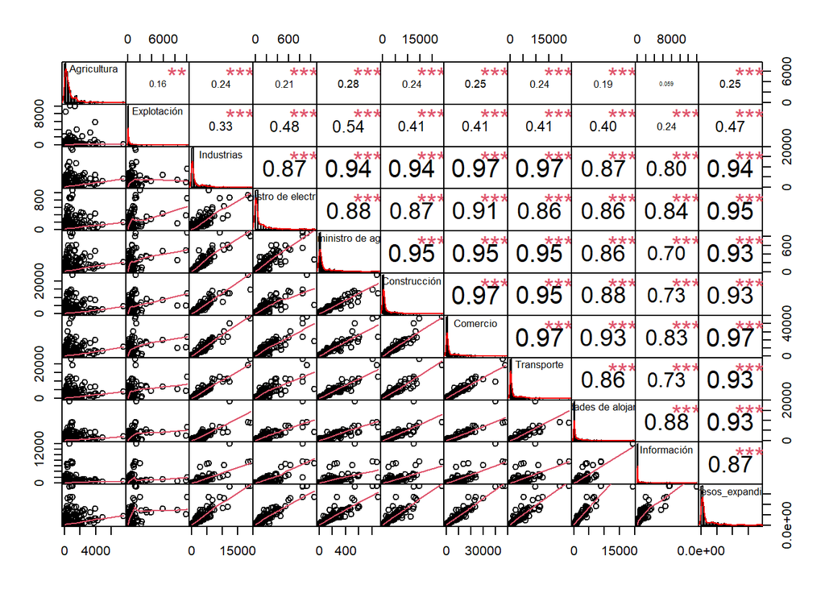

```r
my_data <- df_2017_2[, c(3,6,9,12,15,18,21,24,27,30,73)]
chart.Correlation(my_data, histogram=TRUE,   method = c( "pearson"), pch=20)
```

### 1.3 **Correlaciones parte II**

#### 1.3.1 Pearson

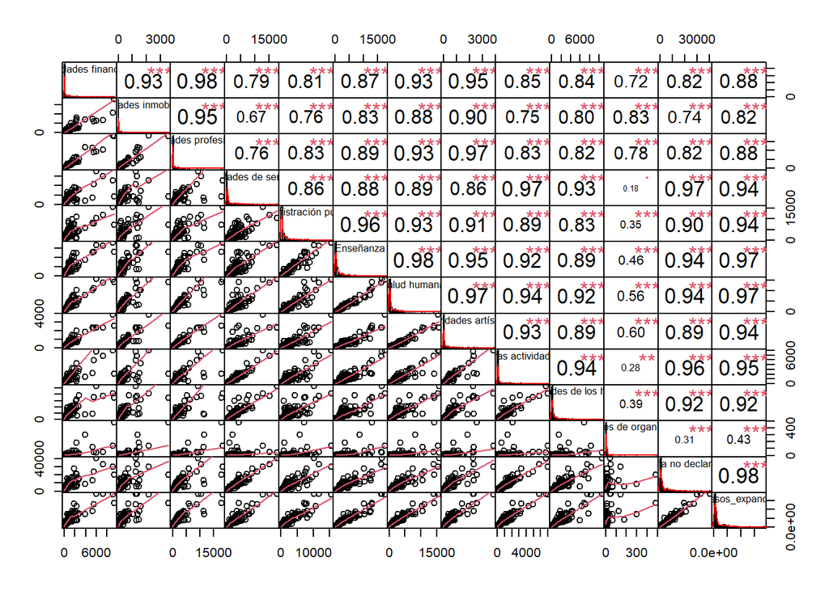

```r
my_data <- df_2017_2[, c(33,36,39,42,45,48,51,54,57,60,63,66,73)]
chart.Correlation(my_data, histogram=TRUE,   method = c( "pearson"), pch=20)
```

### 1.4 **Correlaciones parte I**

#### 1.4.1 Spearman

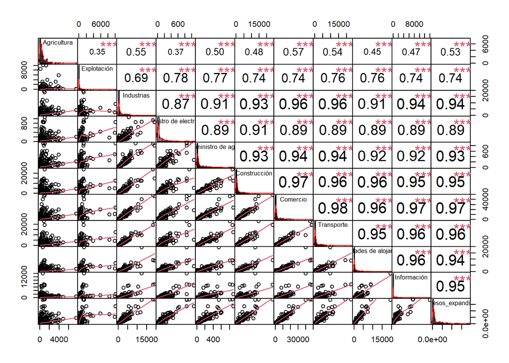

```r
my_data <- df_2017_2[, c(3,6,9,12,15,18,21,24,27,30,73)]
chart.Correlation(my_data, histogram=TRUE,   method = c( "spearman"), pch=20)
```

### 1.5 **Correlaciones parte II**

#### 1.5.1 Spearman

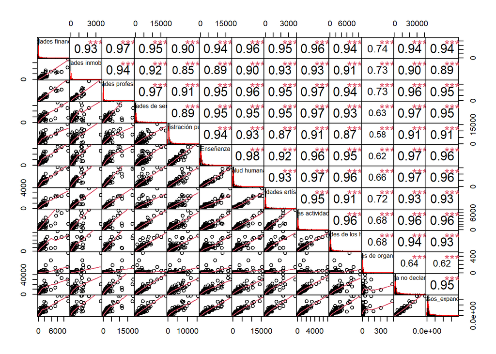

```r
my_data <- df_2017_2[, c(33,36,39,42,45,48,51,54,57,60,63,66,73)]
chart.Correlation(my_data, histogram=TRUE,   method = c( "spearman"), pch=20)
```

### 1.6 **Correlaciones parte I**

#### 1.6.1 Kendall

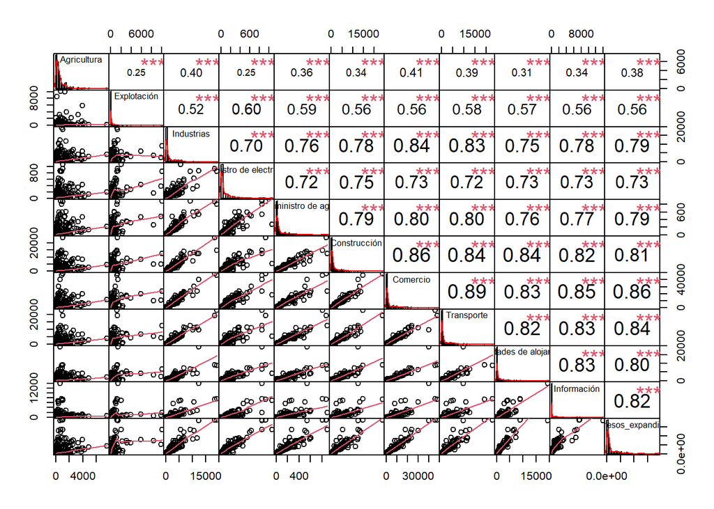

```r
my_data <- df_2017_2[, c(3,6,9,12,15,18,21,24,27,30,73)]
chart.Correlation(my_data, histogram=TRUE,   method = c( "kendall"), pch=20)
```

### 1.6 **Correlaciones parte II**

#### 1.6.1 Kendall

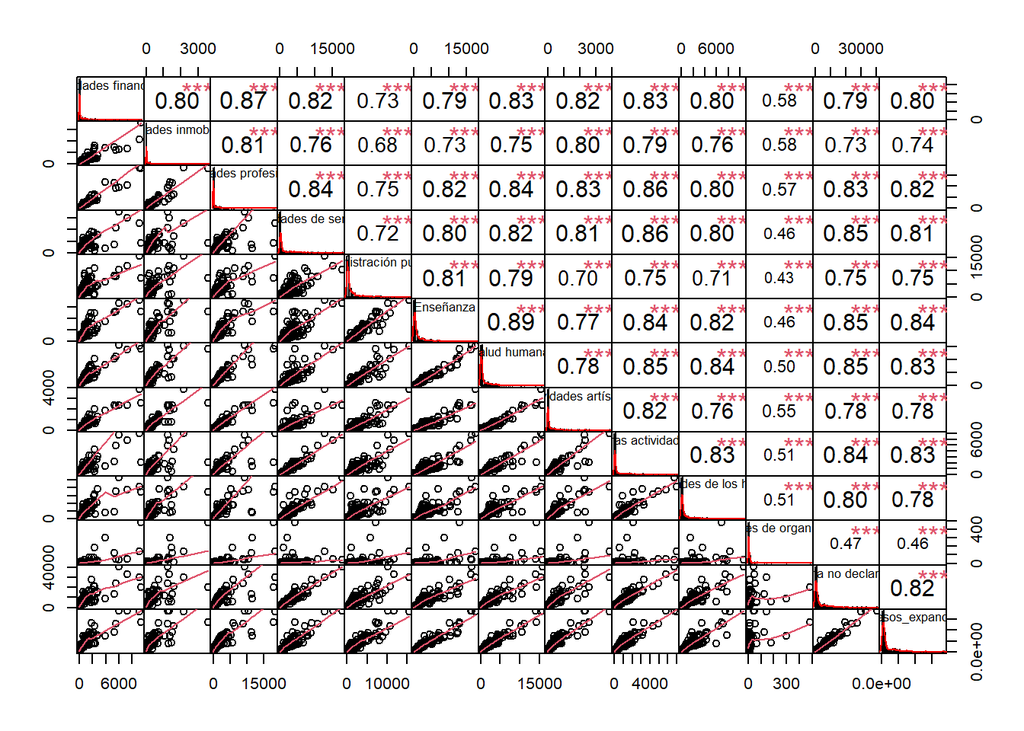

```r
my_data <- df_2017_2[, c(33,36,39,42,45,48,51,54,57,60,63,66,73)]
chart.Correlation(my_data, histogram=TRUE,   method = c( "kendall"), pch=20)
```

# Rural

## 1 Pregunta **P18**: Rama de actividad económica

1 A Agricultura, ganadería, silvicultura y pesca  
2 B Explotación de minas y canteras  
3 C Industrias manufactureras  
4 D Suministro de electricidad, gas, vapor y aire acondicionado  
5 E Suministro de agua; evacuación de aguas residuales, gestión de desechos y descontaminación  
6 F Construcción  
7 G Comercio al por mayor y al por menor; reparación de vehículos automotores y motocicletas  
8 H Transporte y almacenamiento  
9 I Actividades de alojamiento y de servicios de comidas  
10 J Información y comunicaciones  
11 K Actividades financieras y de seguros  
12 L Actividades inmobiliarias  
13 M Actividades profesionales, científicas y técnicas  
14 N Actividades de servicios administrativos y de apoyo  
15 O Administración pública y defensa; planes de seguridad social de afiliación obligatoria  
16 P Enseñanza  
17 Q Actividades de atención de la salud humana y de asistencia social  
18 R Actividades artísticas, de entretenimiento y recreativas  
19 S Otras actividades de servicios  
20 T Actividades de los hogares como empleadores; actividades no diferenciadas de los hogares como productores de bienes y servicios para uso propio  
21 U Actividades de organizaciones y órganos extraterritoriales  
22 Z Rama no declarada

98 No aplica  
99 Missing

### 1.1 Cálculo de frecuencias

```r
tabla_con_clave <- readRDS("../censo_personas_con_clave_17")
tabla_con_clave <- filter(tabla_con_clave, tabla_con_clave$AREA == 2)

b <- tabla_con_clave$COMUNA
c <- tabla_con_clave$P18
cross_tab =  xtabs( ~ unlist(b) + unlist(c))
tabla <- as.data.frame(cross_tab)
d <-tabla[!(tabla$Freq == 0),]
d$anio <- "2017"

d$unlist.c. <- as.character(d$unlist.c.)
d <- d[-5]

d$unlist.c.[d$unlist.c. == "A"] <- "1"
d$unlist.c.[d$unlist.c. == "B"] <- "2"
d$unlist.c.[d$unlist.c. == "C"] <- "3"
d$unlist.c.[d$unlist.c. == "D"] <- "4"
d$unlist.c.[d$unlist.c. == "E"] <- "5"

d$unlist.c.[d$unlist.c. == "F"] <- "6"
d$unlist.c.[d$unlist.c. == "G"] <- "7"
d$unlist.c.[d$unlist.c. == "H"] <- "8"
d$unlist.c.[d$unlist.c. == "I"] <- "9"
d$unlist.c.[d$unlist.c. == "J"] <- "10"

d$unlist.c.[d$unlist.c. == "K"] <- "11"
d$unlist.c.[d$unlist.c. == "L"] <- "12"
d$unlist.c.[d$unlist.c. == "M"] <- "13"
d$unlist.c.[d$unlist.c. == "N"] <- "14"
d$unlist.c.[d$unlist.c. == "O"] <- "15"

d$unlist.c.[d$unlist.c. == "P"] <- "16"
d$unlist.c.[d$unlist.c. == "Q"] <- "17"
d$unlist.c.[d$unlist.c. == "R"] <- "18"
d$unlist.c.[d$unlist.c. == "S"] <- "19"
d$unlist.c.[d$unlist.c. == "T"] <- "20"

d$unlist.c.[d$unlist.c. == "U"] <- "21"
d$unlist.c.[d$unlist.c. == "Z"] <- "22"

d$unlist.c. <- as.numeric(d$unlist.c.)

d_t <- filter(d,d$unlist.c. == 1)
for(i in 2:22){
  d_i <- filter(d,d$unlist.c. == i)
  d_t = merge( x = d_t, y = d_i, by = "unlist.b.", all.x = TRUE)
}

codigos <- d_t$unlist.b.
rango <- seq(1:nrow(d_t))
cadena <- paste("0",codigos[rango], sep = "")
cadena <- substr(cadena,(nchar(cadena)[rango])-(4),6)
codigos <- as.data.frame(codigos)
cadena <- as.data.frame(cadena)
comuna_corr <- cbind(d_t,cadena)
comuna_corr <- comuna_corr[,-c(1),drop=FALSE]

names(comuna_corr)[67] <- "código"

ingresos_expandidos_2017 <- readRDS("Ingresos_expandidos_rural_17.rds")

df_2017_2 = merge( x = comuna_corr, y = ingresos_expandidos_2017, by = "código", all.x = TRUE)

names(df_2017_2)[3] <- "Agricultura"
names(df_2017_2)[6] <- "Explotación"
names(df_2017_2)[9] <- "Industrias"
names(df_2017_2)[12] <- "Suministro de electricidad"
names(df_2017_2)[15] <- "Suministro de agua"
names(df_2017_2)[18] <- "Construcción"
names(df_2017_2)[21] <- "Comercio"
names(df_2017_2)[24] <- "Transporte"
names(df_2017_2)[27] <- "Actividades de alojamiento"
names(df_2017_2)[30] <- "Información"

names(df_2017_2)[33] <- "Actividades financieras"
names(df_2017_2)[36] <- "Actividades inmobiliarias"
names(df_2017_2)[39] <- "Actividades profesionales"
names(df_2017_2)[42] <- "Actividades de servicios"
names(df_2017_2)[45] <- "Administración pública"
names(df_2017_2)[48] <- "Enseñanza"
names(df_2017_2)[51] <- "salud humana"
names(df_2017_2)[54] <- "Actividades artísticas"
names(df_2017_2)[57] <- "Otras actividades"
names(df_2017_2)[60] <- "Actividades de los hogares"

names(df_2017_2)[63] <- "Actividades de organizaciones"
names(df_2017_2)[66] <- "Rama no declarada"
```

### 1.2 **Correlaciones parte I**

#### 1.2.1 Pearson

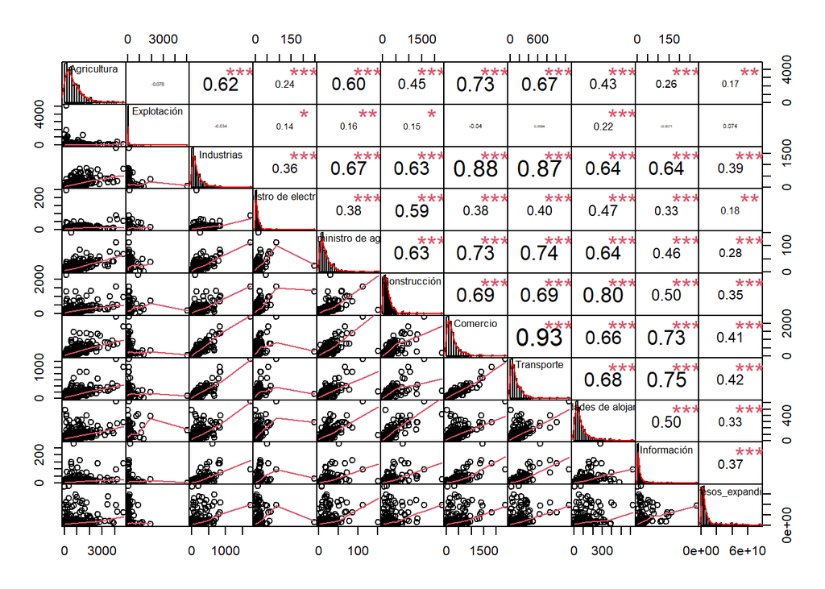

```r
my_data <- df_2017_2[, c(3,6,9,12,15,18,21,24,27,30,73)]
chart.Correlation(my_data, histogram=TRUE,   method = c( "pearson"), pch=20)
```

### 1.3 **Correlaciones parte II**

#### 1.3.1 Pearson

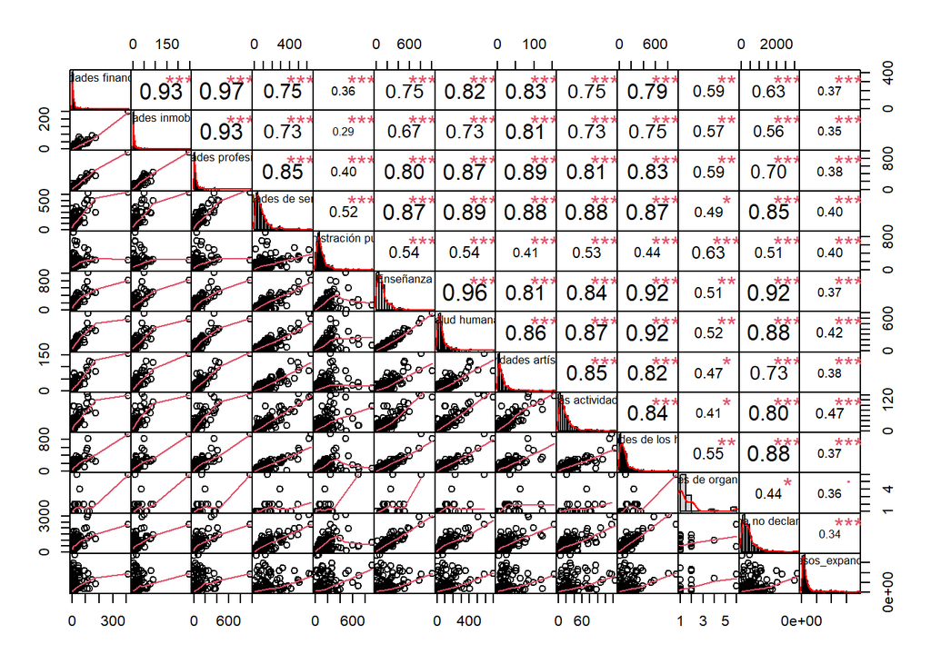

```r
my_data <- df_2017_2[, c(33,36,39,42,45,48,51,54,57,60,63,66,73)]
chart.Correlation(my_data, histogram=TRUE,   method = c( "pearson"), pch=20)
```

### 1.4 **Correlaciones parte I**

#### 1.4.1 Spearman

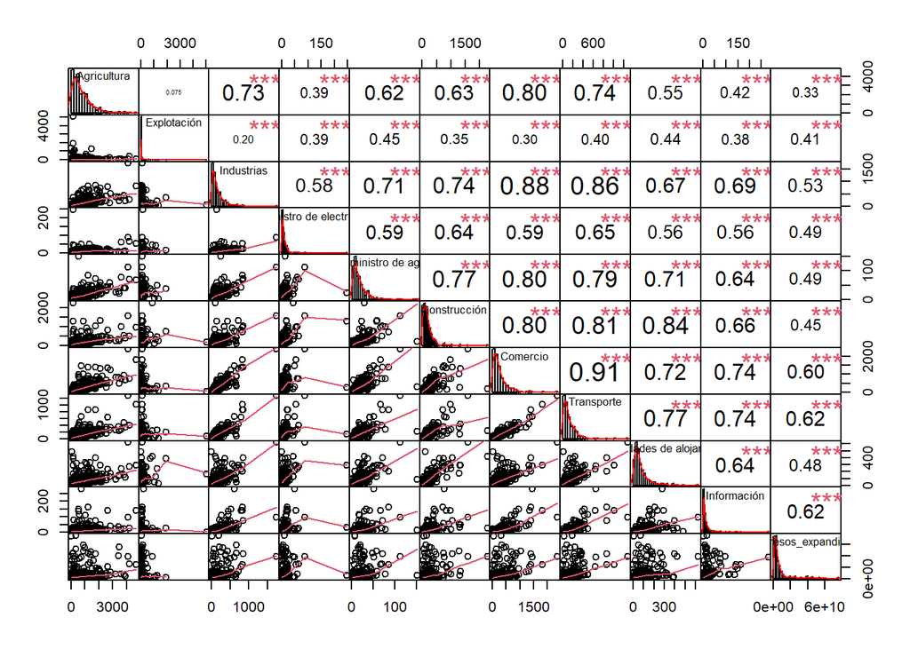

```r
my_data <- df_2017_2[, c(3,6,9,12,15,18,21,24,27,30,73)]
chart.Correlation(my_data, histogram=TRUE,   method = c( "spearman"), pch=20)
```

### 1.5 **Correlaciones parte II**

#### 1.5.1 Spearman

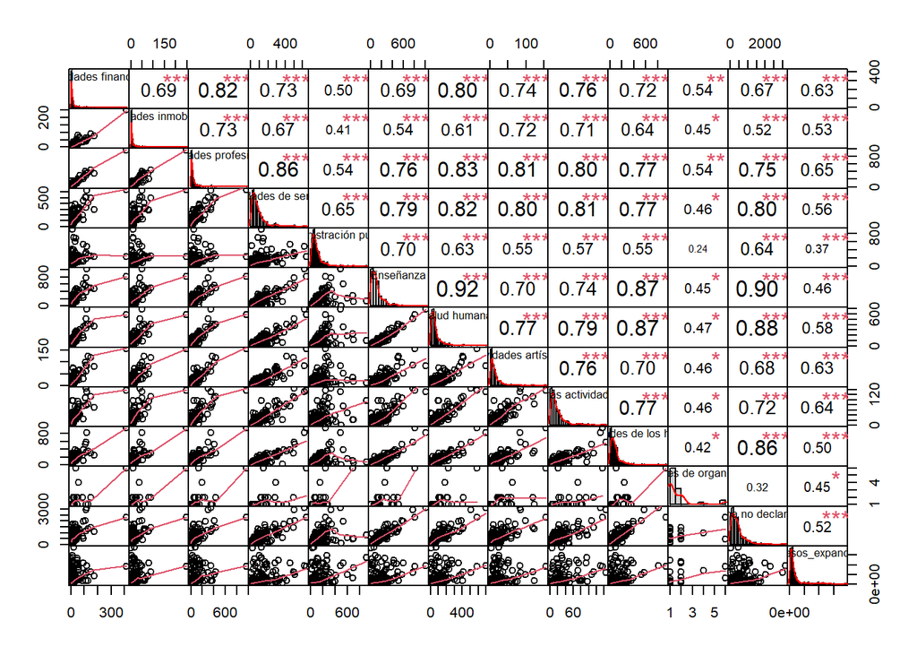

```r
my_data <- df_2017_2[, c(33,36,39,42,45,48,51,54,57,60,63,66,73)]
chart.Correlation(my_data, histogram=TRUE,   method = c( "spearman"), pch=20)
```

### 1.6 **Correlaciones parte I**

#### 1.6.1 Kendall

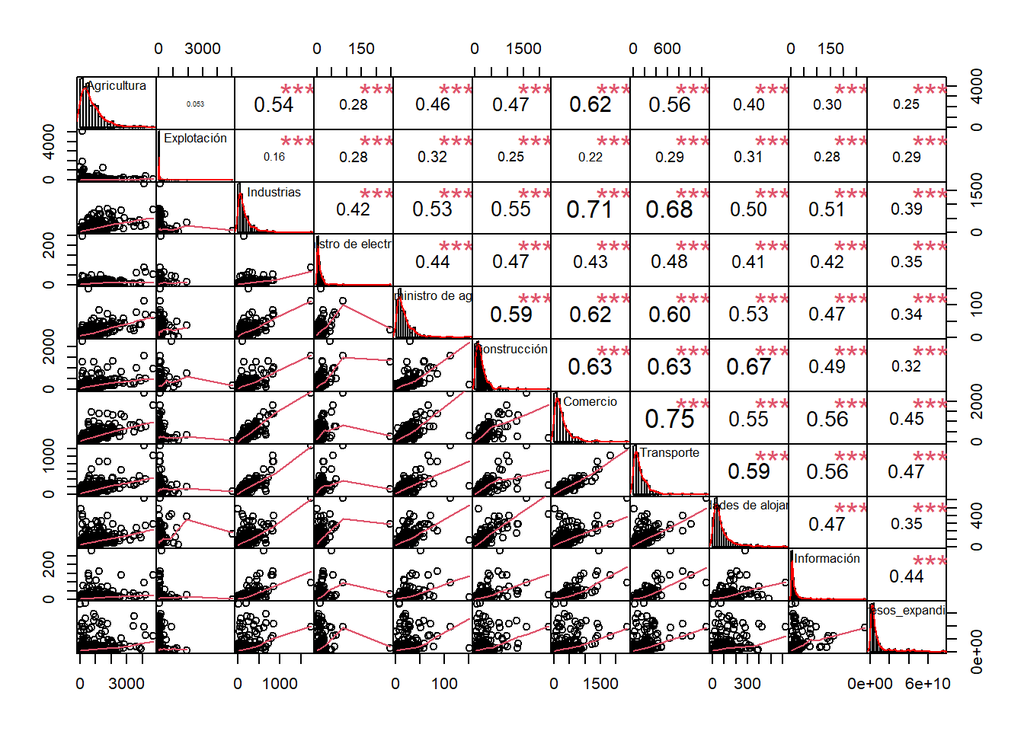

```r
my_data <- df_2017_2[, c(3,6,9,12,15,18,21,24,27,30,73)]
chart.Correlation(my_data, histogram=TRUE,   method = c( "kendall"), pch=20)
```

### 1.6 **Correlaciones parte II**

#### 1.6.1 Kendall

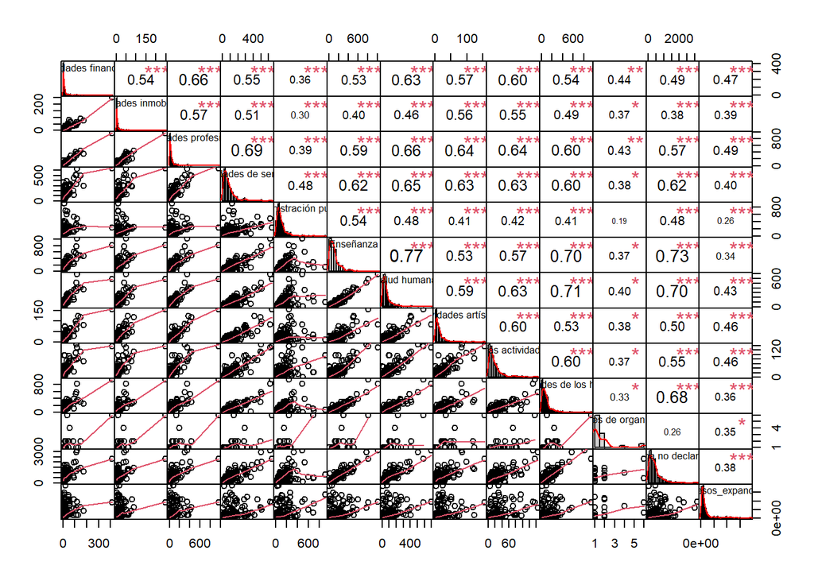

```r
my_data <- df_2017_2[, c(33,36,39,42,45,48,51,54,57,60,63,66,73)]
chart.Correlation(my_data, histogram=TRUE,   method = c( "kendall"), pch=20)
```